# R 數值預估評估方法

Ivan Lin

2020年4月18日

## 模型評估-驗證指標(validation index)

若將預測這件事簡單區分成兩大種類，大致可分為  
1. 機率預測，比如會不會下雨、下一張牌的紅心A…  
2. 數值預測，比如預測下一季的銷售量、捷運站的客流量…  
我們利用所蒐集到的資料訓練出模型進行預測，然而怎麼評估模型成效(Performance)呢？

我們會使用驗證指標(validation index)來當作成效參考，對應到機器學習領域，依據應用分為「分類指標」和「回歸指標」。

**機率預測的「分類指標」**:  
- 二元相關：混淆矩陣confusion matrix和相對應驗證指標、ROC曲線、AUC。  
- 多元相關：多元混淆矩陣和相對應驗證指標。

**數值預測的「回歸指標」**:  
- 絕對誤差(Absolute Error, E)、相對誤差(Relative Error, e)  
- 平均絕對誤差(Mean Absolute Error, MAE)  
- 平均均方誤差(Mean Squared Error, MSE)  
- 平均均方對數誤差(Mean Squared Logarithmic Error, MSLE)  
- 正歸化均方誤差、均方根誤差

這篇先來介紹數值預測的迴歸指標，相對比較容易一些。

## 數值回歸前情提要

在講述數值模型評估方法前，還是不厭其煩的前情提要，數值預估多採用線性回歸（Linear regression），是找出自變數(independent variable)和依變數(dependent variable)之間的關係建立出來的模型。

白話來說，就是找到一條公式，可以解釋自變數$x$(或稱內生變數endogenous variable)與依變數$y$(外生變數exogenous variable)的關係，也就是 $y=bx+a$

當只有一個自變數和一個依變數的情形稱為簡單線性回歸(Simple linear regression)，超過一個自變數的情形稱為多元回歸(multiple regression)。

## 數值預測評估方法

對於數值預測的效果評估，「回歸指標」主要是比較真實數值與預測結果，例如預測銷售量為25645，預測為24332，比較兩者差異值1313，即為最簡單的絕對誤差，從此概念延伸有許多的誤差計算法，觀察真實數列與預測數列的接近程度，越接近就表示預測模型效果越好。

下面就要介紹常見的評估指標，首先

我們討論時，假設資料列共有n個值，以符號代表：  
$y_{i}$代表真實值  
$\hat{y_{i}}$代表預測值  
$i\in[1,n]$  
另外！自由度的問題會擺在後面討論。

## 絕對誤差(Absolute Error, E)

$$E_{i}= y_{i}-\hat{y_{i}}$$
很直覺，真實值和預測值差異，其值當然是越小越好，絕對誤差有正負之分(但也有些教科書取絕對值)。
這裡我們參考[Wiki](https://zh.wikipedia.org/wiki/%E8%AF%AF%E5%B7%AE)上的定義。 從樣本所估計得到的誤差為“殘差(Residual)”，誤差與殘差的差別我在後面討論！。 舉例：預測今天總來客數是1500人，實際上是1600人，差了-100即為E。

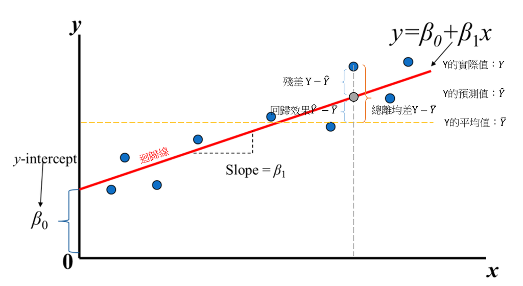

這張圖修改自[Tommy線性回歸](https://medium.com/@chih.sheng.huang821/%E7%B7%9A%E6%80%A7%E5%9B%9E%E6%AD%B8-linear-regression-3a271a7453e) 不得不推Tommy大的Medium非常精彩！  
這張圖上的殘差就是這裡說的E，真實值、預測值、平均值之間的關係都可以用符號代表。

## 相對誤差(Relative Error, e)；百分誤差

$$e_{i}=\frac{y_{i}-\hat{y_{i}}}{y_{i}}$$
將絕對誤差除上真實值，大多數情況能將數值控制在1與-1之間。此時失去單位，可用做不同預測值間的比較。 承上例，-100/1500= -0.06 ;約為 6%

## 平均絕對誤差(Mean Absolute Error, MAE)

$$MAE=\frac{1}{n}\sum_{i=1}^{n} \left |E_{i} \right |=\frac{1}{n}\sum_{i=1}^{n} \left |y_{i}-\hat{y_{i}} \right |$$
討論點估計看E和e。
對整個預測數列評估時，則要看整體的誤差分佈狀況，然而拿有正負號的絕對誤差E直接相加會有問題。舉例：
下午一點預測來客數1600，實際1500，絕對誤差E為-100
下午兩點預測來客數1800，實際1900，絕對誤差E為100
直接相加為0，無法當作模型評估指標，因此改取絕對值相加後平均，MAE則為100。
白話來說就是，我這個預測模型平均會有差不多正負100的誤差！ 但事實上取絕對值的方法在統計上不常用。

註：error和deviation的含義是一樣的，所以Mean Absolute Error也可稱做Mean Absolute Deviation(MAD)，其他指標同理。

## 平均百分相對誤差(Mean Percentage Error, MPE)

$$MPE=\frac{100%}{n}\sum_{i=1}^{n} e_{i} =\frac{1}{n}\sum_{i=1}^{n} \frac{y_{i}-\hat{y_{i}}}{y_{i}}$$

## 平均絕對百分誤差(MAPE, Mean Absolute Percentage Error)

$$MAPE=\frac{100}{n}\sum_{i=1}^{n} \left |e_{i} \right |=\frac{100}{n}\sum_{i=1}^{n} \left|\frac{y_{i}-\hat{y_{i}}}{y_{i}}\right|$$
是取相對誤差(e)絕對值之和的平均值，大致可感受偏差的平均程度。
是經常被拿來使用的數值評估指標，一般來說MAPE < 10%的模型為可接受的。
但有一點需要非常注意，若實際值出現0，會使得e變無窮大，為了避免這個 bug，MAPE一般用於實際值不會為0的情形。

## 均方誤差(Mean Squared Error, MSE)

$$MSE=\frac{1}{n}\sum_{i=1}^{n} E_{i}^{2} =\frac{1}{n}\sum_{i=1}^{n} (y_{i}-\hat{y_{i}})^{2}$$

跟平均誤差類似，但平方除了可以避開正負不能相加的問題，還可以放大誤差的作用。 用這個例子感受一下差別：

```r
diff=c(1,-2,1,-4,100)
MAE_diff=mean(abs(diff));MAE_diff
```

```
## [1] 21.6
```

```r
MSE_diff=mean(diff^2);MSE_diff
```

```
## [1] 2004.4
```

## 正歸化均方誤差(Normalized Mean Squared Error, NMSE)

先看熟悉的離均差平方合sum of square $SS_{t}= \sum_{i=1}^{n} (y_{i}-\bar{y})^{2}$
$SS_{t}$是用來分析原始資料的離散程度。 我們將$MSE/SS_{t}$得到正歸化後的NMSE：
$$NMSE=\frac{SS_{e}}{SS_{t}}=\frac{\sum_{i=1}^{n} (y_{i}-\hat{y_{i}})^{2} }{\sum_{i=1}^{n} (y_{i}-\bar{y})^{2} }$$
原本的MSE還帶著單位平方，正歸化後較適合比較。
NMSE的值超過1時，表示模型很糟糕，越小越好。

## 均方根誤差（Root Mean Squared Error, RMSE)

簡單來說就是對MSE開根號，表示預測值與真實值的平均偏離程度，仔細看就會發現算法跟標準差有雷同概念
$$RMSE=\sqrt{\frac{1}{n}\sum_{i=1}^{n} {E_{i}}^{2}}=\sqrt{\frac{1}{n}\sum_{i=1}^{n}(y_{i}-\hat{y_{i}})^{2}}$$

## 平均均方對數誤差(Mean Squared Logarithmic Error, MSLE)

$$MSLE=\frac{1}{n}\sum_{i=1}^{n}\left ( ln(1+y_{i})-ln(1+\hat{y_{i}})\right)^{2}$$

## 希爾不等係數(Theil inequality coefficient, TIC)

$$TIC=\frac{\sqrt{\frac{1}{n}\sum_{i=1}^{n}(y_{i}-\hat{y_{i}})^{2}}}{\sqrt{\frac{1}{n}\sum_{i=1}^{n}y_{i}^{2}}+\sqrt{\frac{1}{n}\sum_{i=1}^{n}\hat{y_{i}}^{2}}}$$

其值介於0到1之間，越小預測效果越好。

看到這裡是不是頭暈了呢？其實還有許多衍伸變化，不過皆大同小異概念雷同。  
太多公式無法記住全部沒關係，重點是這些指標都是值越小表示模型越好！  
眾多模型比較時，只要選定適合的，即可開始比較各模型的驗證指標(validation index)。  
其中RMSE請一定要記得！

## 判定係數(Coefficient of Determination, R squared)

$R^{2}$這各位肯定不陌生，另外還有常見的Adjusted$R^{2}$
其為最常用來反映回歸模型解釋力的統計量。使用在很多統計書上都有描述，但千萬要小心一知半解的使用，尤其是把它跟相關係數(coefficient of correlation, r)搞混。
又稱為「決定係數」或者「擬合度」，亦可理解為誤差百分比(precentage of reduced error, PRE)，反映的是預測值對實際值的解釋程度。
其值通常介於0-1之間，$R^{2}$越接近1，預測值越接近真實值。
$$R^{2}=1-\frac{SS_{e}}{SS_{t}}=1-\frac{\sum_{i=1}^{n} (y_{i}-\hat{y_{i}})^{2} }{\sum_{i=1}^{n} (y_{i}-\bar{y})^{2} }$$
$SS_{t}=\sum(y-\bar{y})^{2}$為總變異量
$SS_{e}=\sum(y-\hat{y})^{2}$為殘差(誤差)變異量
$SS_{regression}=\sum(\hat{y}-\bar{y})^{2}$則是回歸可解釋的變異量

依變數Y的總變異量$SS_{t}$ 可以拆解成 可被迴歸模型解釋的回歸變異量$SS_{regression}$與不可解釋的殘差(誤差)變異量$SS_{e}$
$$SS_{t}=SS_{regression}+SS_{e}$$
$$\sum(y-\bar{y})^{2}=\sum(y-\hat{y})^{2}+\sum(\hat{y}-\bar{y})^{2}$$
對於總離差平方和怎麼拆解的，我在另外一篇文章[SST拆解證明](https://rpubs.com/ivan0628/SST-disassemble)討論。

我們用比例的概念來思考，如果總變異量為1，那麼迴歸模型解釋的百分比佔多少，殘差又佔多少？
$$1=\frac{SS_{regression}}{SS_{t}}+\frac{SS_{e}}{SS_{t}}$$

回歸可解釋的變異量
$$R^{2}=\frac{SS_{regression}}{SS_{t}}=1-\frac{SS_{e}}{SS_{t}}$$

一般來說，$R^{2}$越大，表示模型擬合效果越好。  
模型解釋了多少，反映的就是大概有多準，隨著樣本數量的增加，$R^{2}$必然增加，無法真正說明準確程度，只能大概定量。

多大的值才代表模型的精度高呢？這個其實沒有統一的標準。但依經驗歸納如下：  
$R^{2}$的值大於0.75，表示迴歸模型擬合度很好，迴歸方程的可解釋程度較高，即迴歸方程的精度較高。 $R^{2}$的值在0.5和0.75之間，表示迴歸模型的擬合可以接受，但需要進一步修正迴歸模型。 $R^{2}$的值小於0.5，表示迴歸模型擬合有問題，我們需要調整自變量重新進行迴歸分析。

## 校正判定係數（Adjusted R-Square）

我們做回歸時會增減自變數來調整模型，當加入的自變數越多，$R^{2}$會越大，呈現高估的現象。這會顯得迴歸方程擬合效果很好。但實際上可能並非如此，有些自變量與因變量完全不相關，增加這些自變量，並不會提升擬合水平和預測精度，但卻能提高判定係數$R^{2}$的值。因此經過自由度的調整，可避免 $R^{2}$的膨脹。

對判定係數$R^{2}$進行調整採用的方法是，用樣本量n和自變量的個數k去進行調整。
$${R_{adjusted}}^{2}=1-\frac{\frac{SS_{e}}{n-k-1}}{\frac{SS_{t}}{n-1}}$$

做一些整理
$${R_{adjusted}}^{2}=1-\frac{n-1}{n-k-1}\frac{SS_{e}}{SS_{t}}=1-\frac{n-1}{n-k-1}(1-R^{2})$$
從公式中可以看出，當加入的自變數個數K越大，會導致後項越大，使${R_{adjusted}}^{2}$越小。
因為(n-1)永遠大於(n-k-1)，所以多元迴歸中，調整後的判定係數${R_{adjusted}}^{2}$永遠小於判定係數$R^{2}$。

因調整後的判定係數${R_{adjusted}}^{2}$較判定係數$R^{2}$測算更全面也更準確，所以，在迴歸分析尤其是多元迴歸分析中，我們通常使用調整後的R2對迴歸方程的精度進行測算和評定，以評估迴歸方程的擬合度和迴歸分析預測的效果。

這邊我們用Iris資料集做個示範：

```r
#預測Length，放所有變數
lm.fit <- lm(Sepal.Length~.,data=iris)
summary(lm.fit)
```

```
##
## Call:
## lm(formula = Sepal.Length ~ ., data = iris)
##
## Residuals:
##      Min       1Q   Median       3Q      Max
## -0.79424 -0.21874  0.00899  0.20255  0.73103
##
## Coefficients:
##                   Estimate Std. Error t value Pr(>|t|)
## (Intercept)        2.17127    0.27979   7.760 1.43e-12 ***
## Sepal.Width        0.49589    0.08607   5.761 4.87e-08 ***
## Petal.Length       0.82924    0.06853  12.101  < 2e-16 ***
## Petal.Width       -0.31516    0.15120  -2.084  0.03889 *
## Speciesversicolor -0.72356    0.24017  -3.013  0.00306 **
## Speciesvirginica  -1.02350    0.33373  -3.067  0.00258 **
## ---
## Signif. codes:  0 '***' 0.001 '**' 0.01 '*' 0.05 '.' 0.1 ' ' 1
##
## Residual standard error: 0.3068 on 144 degrees of freedom
## Multiple R-squared:  0.8673, Adjusted R-squared:  0.8627
## F-statistic: 188.3 on 5 and 144 DF,  p-value: < 2.2e-16
```

同判定係數$R^{2}$一樣，習慣上在迴歸分析中，會用0.5當作調整後的${R_{adjusted}}^{2}$的臨界值，如果調整後的${R_{adjusted}}^{2}$小於0.5，則要分析我們所採用和未採用的自變量，調整迴歸方程，重新進行迴歸分析。

另外，在進行迴歸方程精度評定時，還需注意如果調整後的${R_{adjusted}}^{2}$與判定係數$R^{2}$存在明顯差異，則意味着所用的自變量不能很好的測算因變量的變化，或者是我們遺漏了一些可用的自變量。  
調整後的${R_{adjusted}}^{2}$與判定係數$R^{2}$間差距越大，模型的擬合程度越差。

## R數值評估函數

已經有些相關的套件如[Metrics](https://www.rdocumentation.org/packages/Metrics/versions/0.1.4)可直接引入。  
這邊也跟大家一起練習手刻，函式都很簡單。

```r
#弄一個模擬data
actual    <- c(1.1, 1.9, 3.0, 4.4, 5.0, 5.6)
predicted <- c(0.9, 1.8, 2.5, 4.5, 5.0, 6.2)

if (length(actual) != length(predicted)) {
  print('The legnth of two array is not equal')
}

#使用Metrics套件
  #取絕對值後的E
    aE = ae(actual,predicted)
  #平均絕對誤差 MAE
    MAE = mae(actual,predicted)
  #平均絕對百分誤差 MAPE
    MAPE = mape(actual,predicted)
  #均方誤差 MSE
    MSE = mse(actual, predicted)
  #均方根誤差 RMSE
    RMSE = rmse(actual, predicted)
  #平均均方對數誤差 MSLE
    MSLE = msle(actual, predicted)

#手刻
  #絕對誤差 E
    E = actual-predicted
  #取絕對值後的E
    aE  = abs(actual-predicted) #自己寫
  #相對誤差 e
    e = (actual-predicted)/actual
  #平均絕對誤差 MAE
    MAE = 1/length(actual)*sum(abs(actual-predicted))
  #平均絕對百分誤差 MAPE
    MAPE = 1/length(actual)*sum(abs((actual-predicted)/actual))
  #均方誤差 MSE
    MSE = 1/length(actual)*sum((actual-predicted)^2)
  #正規化均方誤差 NMSE
    NMSE = sum((actual-predicted)^2)/sum((actual-mean(actual))^2)
  #均方根誤差 RMSE
    RMSE = sqrt(1/length(actual)*sum((actual-predicted)^2))
  #平均均方對數誤差 MSLE
    MSLE = 1/length(actual)*sum((log(1+actual,base=exp(1))-log(1+predicted,base=exp(1)))^2)

  #R Squared
    R_squared = 1-sum((actual-predicted)^2)/sum((actual-mean(actual))^2)
```

實務上在R中我們不會去看這麼多指標，慣用的是直接用summary去檢討回歸模型。 Residual standard error即為殘差項的RMSE。

## 迴歸分析的假設檢定

### R squared的顯著性檢定

前面已經說明了迴歸模型的變異數拆解原理。  
其中有個問題，當$R^{2}$很高時，是否就代表模型很好！？ 其實不然，若要說$R^{2}$具統計意義，還得通過顯著性檢定。

### F Test

我們在前面討論均方誤差時，其實簡化了自由度的討論。
實際上n的位置應代入自由度$df$
公式修正如下：
$$MSE=\frac{1}{df_{e}}\sum_{i=1}^{n} E_{i}^{2} =\frac{1}{df_{e}}\sum_{i=1}^{n} (y_{i}-\hat{y_{i}})^{2}$$
而針對回歸值，也可以計算回歸效果變異數：
$$MSRegression=\frac{1}{df_{Reg}}\sum_{i=1}^{n} (\hat{y_{i}}-\bar{y})^{2}$$

這兩個變異數的比值可以透過F檢定進行顯著性考驗。 此時$H_{0}$表示，「回歸可解釋變異量為0」，如果無法推翻，即使$R^{2}$再高，也沒有統計上的意義。
F檢定探討迴歸模型中的迴歸係數β（就是各因子的權重）是否全部為0。當係數不全為0時，迴歸模型才具有預測力。
虛無假說(Null hypothesis)：$H_{0}：\beta_{1}=\beta_{2}=...=\beta_{p}=0$
對立假說(alternative hypothesis)：$H_{0}：\beta_{1},\beta_{2},...,\beta_{p}\neq 0$
F檢定量的統計值(Statistics)：
$$F=\frac{MSRegression}{MSE}=\frac{\frac{SS_{reg}}{df_{reg}}}{\frac{SS_{e}}{df_{e}}}=\frac{\frac{SS_{reg}}{p}}{\frac{SS_{e}}{N-P-1}}$$

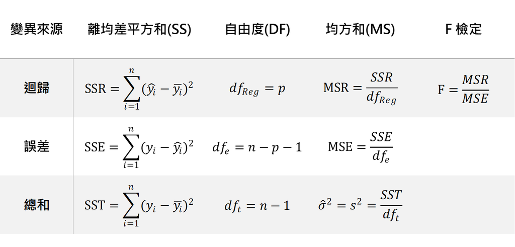

R變異量分析表

可以對應到下方R Summary的結果。  
## R 中 Linear Model Summary 的各項含意

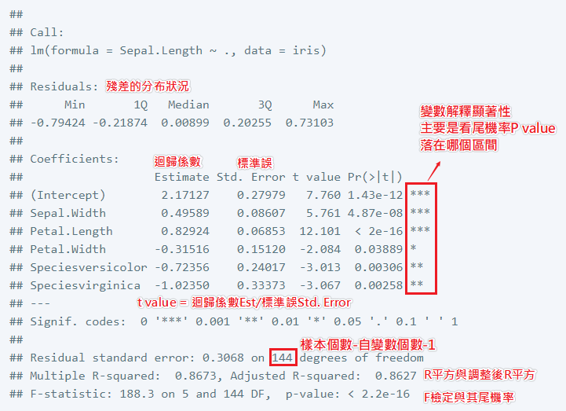

## 迴歸分析的基本假設

當我們建立出一個線性回歸時，必須要確認其殘差(residual)是否符合下面三個假設：  
- 常態性(Normality)  
- 獨立性(Independence)  
- 變異數同質性；等分散性(Homogeneity of Variance)

我們先從回歸模型中找到殘差的值，這邊延續上面iris的model介紹。

```r
names(lm.fit) #可以看model內有甚麼參數
```

```
##  [1] "coefficients"  "residuals"     "effects"       "rank"
##  [5] "fitted.values" "assign"        "qr"            "df.residual"
##  [9] "contrasts"     "xlevels"       "call"          "terms"
## [13] "model"
```

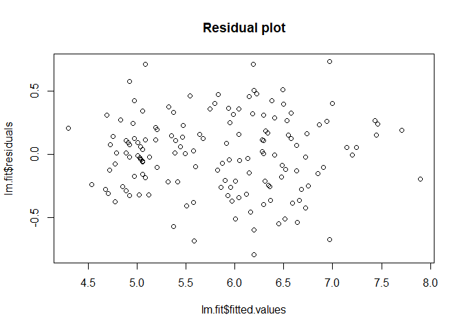

```r
plot(lm.fit$fitted.values,lm.fit$residuals ,main="Residual plot")
```

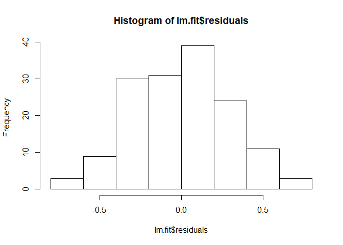

```r
hist(lm.fit$residuals)#殘差的分布情況
```

### 常態性假設

`shapiro.test()`函式可以用來檢驗殘差的常態性：

```r
shapiro.test(lm.fit$residuals)
```

```
##
##  Shapiro-Wilk normality test
##
## data:  lm.fit$residuals
## W = 0.99538, p-value = 0.9202
```

由於**虛無假設H0**:殘差服從常態分配，因為p-value > 0.05，代表不會拒絕H0，也就是殘差符合常態分布！

### 獨立性假設

要檢驗殘差的獨立性，可用套件car中的`durbinWatsonTest()`函式：

```r
car::durbinWatsonTest(lm.fit) #注意，這裡放的是模型本身，函式會自動抓殘差欄位
```

```
##  lag Autocorrelation D-W Statistic p-value
##    1      0.01099141      1.965705   0.708
##  Alternative hypothesis: rho != 0
```

由於**虛無假設H0**:殘差間相互獨立，因p-value > 0.05，代表不會拒絕H0，也就是殘差無自相關。 殘差自相關現象在時間序列分析較常發生。 其實殘差自相關仍可繼續分析，只是殘差變異量可能產生偏誤，進而影響到$R^{2}$導致迴歸模型被拒絕。

### 同質性(等分散性)假設

要檢驗殘差的變異數同質性，同樣使用套件car中的`ncvTest()`函式：

```r
car::ncvTest(lm.fit)
```

```
## Non-constant Variance Score Test
## Variance formula: ~ fitted.values
## Chisquare = 2.715134, Df = 1, p = 0.099401
```

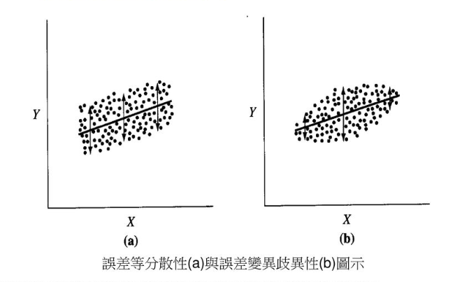

我們用一元的線性回歸圖來解釋：  
圖上X是自變數，Y是依變數。  
殘差不應該隨著X而有所不同，理想上如同圖a，誤差有等分散性。  
但如果在不同的X有不相等的殘差變異量(此即誤差變異歧異性heteroscedasticity)，如圖b，此時表示對Y的預測而言，可能還需其他自變數來解釋。 另外，當研究數據具有值端值存在或非線性關係時，非同質性的現象也容易出現。

推薦參考: [r-bloggers](https://www.r-bloggers.com/how-to-detect-heteroscedasticity-and-rectify-it/)

## ASD (A Standard Deviation)累計圖

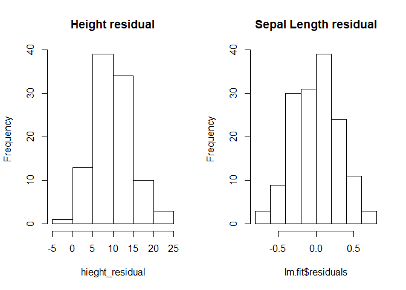

我們可以使用標準差將這張圖標準化，變成累計分布圖(Cumulative Distribution Function)來比較。  
如果各位還記得機率分布，這就跟累積分布函數的計算如出一轍！因此我們也借用R中cdf的function來畫圖。  
作法：將每個殘差除以真實值$y$的標準差，取絕對值，並且畫累積分布圖。

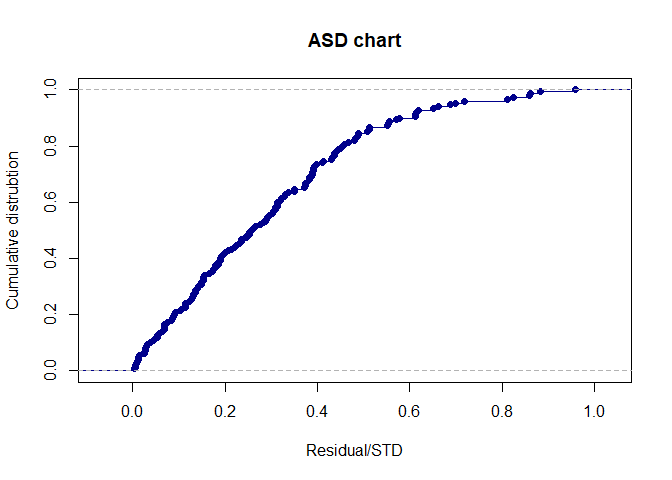

```r
std <- sd(iris$Sepal.Length) #真實值y的標準差
plot(ecdf(abs(lm.fit$residuals/std)),main="ASD chart",xlab="Residual/STD",ylab="Cumulative distrubtion",col="darkblue")
```

當取線可以越往左偏，曲線下面積越大，表示殘差越小！  
最好的情況是，在X軸上從0往右，曲線能快速拉升，表示大部分的殘差都在很小的標準差範圍內，表示模型極好。  
然而，如果預測中有殘差較大的（已經大於一倍標準差的情況），那麼曲線將不能再一倍標準差的範圍內達到100%。

## 補充：誤差(Error)與殘差(Residual)

誤差與殘差，這兩個概念在某程度上具有很大的相似性，都是衡量不確定性的指標，可是兩者又存在區別。普遍上是蠻常被混著使用的。

簡單理解為：  
誤差$\varepsilon_{i}=y_{i}-E\{y_{i}\}$為 觀測值與 真實回歸線之離差，但是真實迴歸線是未知的。  
殘差$e_{i}=y_{i}-\hat{y_{i}}$為 觀測值與所估計出之迴歸線上的擬合值的偏離，所以是已知的。

誤差是指樣本對母體(無法觀察到的)均值及真實值的均值的偏離。  
殘差則是指樣本和觀察值(樣本總體)或回歸值(預測值)的差異量。

誤差與測量有關，誤差大小可以衡量測量的準確性，誤差越大則表示測量越不準確。  
(1)誤差分為兩類：系統誤差與隨機誤差。  
①系統誤差與測量方案有關，通過改進測量方案可以避免系統誤差。  
②隨機誤差與觀測者，測量工具，被觀測物體的性質有關，只能儘量減小，卻不能避免。  
(2)殘差與預測有關，殘差大小可以衡量預測的準確性。殘差越大表示預測越不準確。殘差與資料本身的分佈特性，回歸方程的選擇有關。

越寫越滿了，原本沒要寫這麼多的！邊寫邊訓練腦袋

資料參考：  
[Skydome資料分析筆記](https://rpubs.com/skydome20/R-Note5-First_Practice)  
[Tommy線性回歸](https://medium.com/@chih.sheng.huang821/%E7%B7%9A%E6%80%A7%E5%9B%9E%E6%AD%B8-linear-regression-3a271a7453e)

如果內容有任何問題或錯誤，歡迎來信跟我聯絡唷！ ivan0628@gmail.com